[Antonio Schettino](https://asch3tti.netlify.com/)

January 15th, 2020

Today we will go through a series of steps that are familiar to many scientist doing empirical work. We will pretend to have collected some data[^1], **clean** them, **visualize** them, and **analyze** them using common statistical models. We will do all these things with the [`tidyverse`](https://www.tidyverse.org/), a collection of **R** packages for data manipulation and plotting that aims at being easily readable not only for machines, but also for humans[^2]. These operations will be run in an environment that ensures computational reproducibility: if you have the initial dataset, you will be able to reproduce the final results with a mouse click.

On your computer, you should already have installed **R** and **RStudio** (if not, follow the instructions for your operating system [here](https://cloud.r-project.org/) and [here](https://rstudio.com/products/rstudio/download/#download)).

# Setup

One possible way to work on a project is to open a new *.R* file and write your code there. However, there are a few disadvantages:

- your collaborators may not have your same folder structure, i.e., where you store data and code
  - you **could** specify a working directory with `setwd()`, e.g., `setwd("NAME/OF/YOUR/DIRECTORY")`
- you cannot know the state of your collaborators’ working environment, e.g., what functions or packages they have already loaded
  - you **could** include, at the beginning of your script, the following lines:
    - `cat("\014")` to clear the console
    - `rm(list = ls())` to clear the environment (but it does **not** unload active packages!)

You **could** do all those things, but… **should** you?

[Jenny Bryan](https://jennybryan.org/) explains the reasons (without threats to commit arson) in [this blog post](https://www.tidyverse.org/blog/2017/12/workflow-vs-script/). The main idea is to package code in a self-contained environment that everyone (including your future self) can run without changing their own environment.

## R Projects

Following Jenny Brian’s suggestion (and to avoid her wrath) we can create a project directly from RStudio:

- click the “File” menu button, then “New Project”
- click “New Directory”
- click “New Project”
- type in the name of the directory to store your project, e.g. “my_project”
- click the “Create Project” button

## Install packages

How to install packages:

```r
install.packages("tidyverse")
```

It’s good to know where your packages are. Type `.libPaths()`.

```
## [1] "/home/aschetti/R/x86_64-pc-linux-gnu-library/3.6"
## [2] "/usr/local/lib/R/site-library"
## [3] "/usr/lib/R/site-library"
## [4] "/usr/lib/R/library"
```

## Load packages

How to load packages:

```r
library(tidyverse)
```

# Data manipulation

The data are in *.dat* format, so we are going to load them using `read.table`.

```r
att <-
  read.table(
    "MixedAttitude.dat", # file name
    header = TRUE # data has headers
  )
```

If you don’t know what a function does, access the help (e.g., `?read.table`).

Let’s have a look at the data. If you have **RStudio**, you can click on the name of the dataset in the *Environment* window (by default on the upper right corner).

You can also type the name of the dataset in the console:

```r
att
```

| ssj | gender | beerpos | beerneg | beerneut | winepos | wineneg | wineneut | waterpos | waterneg | waterneu |
| --- | --- | --- | --- | --- | --- | --- | --- | --- | --- | --- |
| 1 | 1 | 1 | 6 | 5 | 38 | -5 | 4 | 10 | -14 | -2 |
| 2 | 1 | 43 | 30 | 8 | 20 | -12 | 4 | 9 | -10 | -13 |
| 3 | 1 | 15 | 15 | 12 | 20 | -15 | 6 | 6 | -16 | 1 |
| 4 | 1 | 40 | 30 | 19 | 28 | -4 | 0 | 20 | -10 | 2 |
| 5 | 1 | 8 | 12 | 8 | 11 | -2 | 6 | 27 | 5 | -5 |
| 6 | 1 | 17 | 17 | 15 | 17 | -6 | 6 | 9 | -6 | -13 |
| 7 | 1 | 30 | 21 | 21 | 15 | -2 | 16 | 19 | -20 | 3 |
| 8 | 1 | 34 | 23 | 28 | 27 | -7 | 7 | 12 | -12 | 2 |
| 9 | 1 | 34 | 20 | 26 | 24 | -10 | 12 | 12 | -9 | 4 |
| 10 | 1 | 26 | 27 | 27 | 23 | -15 | 14 | 21 | -6 | 0 |

[output cut: 11 more lines]

These are the data of 21 participants who saw **neutral**, **positive**, or **negative** advertisement of **beer**, **wine**, and **water** in 3 separate sessions. They were asked to rate the drinks on a scale ranging from – 100 (*dislike very much*) through 0 (*neutral*) to 100 (*like very much*). Researchers wanted to reduce binge drinking in teenagers, so they hoped that pairing negative imagery with alcoholic beverages would lower these ratings[^3].

## Filtering

Looking at the data, you can see that the ratings of participant #99 are a bit strange… perhaps there was a technical problem, i.e., the rating scale was out of the -100/100 range.

Let’s filter this participant out. More specifically, we keep all participants that are **not** participant #99.

```r
att.filter <-
  att %>%
  filter(ssj != 99)
```

Verify that it worked.

```r
att.filter
```

| ssj | gender | beerpos | beerneg | beerneut | winepos | wineneg | wineneut | waterpos | waterneg | waterneu |
| --- | --- | --- | --- | --- | --- | --- | --- | --- | --- | --- |
| 1 | 1 | 1 | 6 | 5 | 38 | -5 | 4 | 10 | -14 | -2 |
| 2 | 1 | 43 | 30 | 8 | 20 | -12 | 4 | 9 | -10 | -13 |
| 3 | 1 | 15 | 15 | 12 | 20 | -15 | 6 | 6 | -16 | 1 |
| 4 | 1 | 40 | 30 | 19 | 28 | -4 | 0 | 20 | -10 | 2 |
| 5 | 1 | 8 | 12 | 8 | 11 | -2 | 6 | 27 | 5 | -5 |
| 6 | 1 | 17 | 17 | 15 | 17 | -6 | 6 | 9 | -6 | -13 |
| 7 | 1 | 30 | 21 | 21 | 15 | -2 | 16 | 19 | -20 | 3 |
| 8 | 1 | 34 | 23 | 28 | 27 | -7 | 7 | 12 | -12 | 2 |
| 9 | 1 | 34 | 20 | 26 | 24 | -10 | 12 | 12 | -9 | 4 |
| 10 | 1 | 26 | 27 | 27 | 23 | -15 | 14 | 21 | -6 | 0 |

[output cut: 10 more lines]

The symbol **`%>%`** is the **pipe operator** , which allows to serially concatenate functions applied to the same data frame. Read it as **“and then”**. In the example below, we called the data frame `att` **and then** applied the `filter` function to discard participant #99.

## Variable selection

For the exercises in this course, we will only need a subset of variables in this dataset.

Researchers were interested in reducing binge drinking, so we will focus our attention on **negative** imagery and one alcoholic beverage. We choose **beer**, because we are in Belgium. We also need control conditions, i.e., **neutral** imagery and **water**.

In the next code, we will simultaneously **select** and **rename** the variables we want to keep.

```r
att.filter.select <-
  att.filter %>%
  select(
    participant = ssj, # new name = old name
    gender,
    beer_negative = beerneg,
    beer_neutral = beerneut,
    water_negative = waterneg,
    water_neutral = waterneu
  )

head(att.filter.select, n = 5) # show only first 5 rows
```

|  | participant | gender | beer_negative | beer_neutral | water_negative | water_neutral |
| --- | --- | --- | --- | --- | --- | --- |
| 1 | 1 | 1 | 6 | 5 | -14 | -2 |
| 2 | 2 | 1 | 30 | 8 | -10 | -13 |
| 3 | 3 | 1 | 15 | 12 | -16 | 1 |
| 4 | 4 | 1 | 30 | 19 | -10 | 2 |
| 5 | 5 | 1 | 12 | 8 | 5 | -5 |

## Recoding

Let’s look at the variable `gender`:

```r
att.filter.select$gender
```

```
##  [1] 1 1 1 1 1 1 1 1 1 1 2 2 2 2 2 2 2 2 2 2
```

A string of 1s and 2s. It’s easy to get a glimpse of this variable because there are not many observations. When you have more observations, better use `unique`:

```r
unique(att.filter.select$gender)
```

```
## [1] 1 2
```

What type of variable is it?

```r
class(att.filter.select$gender)
```

```
## [1] "integer"
```

Class `integer` has only integer values (i.e., no decimals or complex numbers).

There are many variable types in **R**. An interesting one is `factor`, i.e., variables which can have only a limited number of different values… they are basically **categorical** variables. In our case, it would make sense to consider `gender` as a `factor` with two levels, *male* and *female*. Let’s transform it:

```r
# Field et al. do not specify the coding,
# so we will assume that 1 is female and 2 is male
att.filter.select.recode <-
  att.filter.select %>%
  mutate(sex = recode( # create a new variable 'sex'
    factor(gender), # convert variable 'gender' as factor
    "1" = "female", "2" = "male"
  )) # assign labels to factor levels

head(att.filter.select.recode, n = 5)
```

|  | participant | gender | beer_negative | beer_neutral | water_negative | water_neutral | sex |
| --- | --- | --- | --- | --- | --- | --- | --- |
| 1 | 1 | 1 | 6 | 5 | -14 | -2 | female |
| 2 | 2 | 1 | 30 | 8 | -10 | -13 | female |
| 3 | 3 | 1 | 15 | 12 | -16 | 1 | female |
| 4 | 4 | 1 | 30 | 19 | -10 | 2 | female |
| 5 | 5 | 1 | 12 | 8 | 5 | -5 | female |

Now we have two variables with identical information… let’s get rid of `gender`:

```r
att.filter.select.recode <- # over-write the previous data frame
  att.filter.select.recode %>%
  select(-gender) # discard unused variables with '-'

head(att.filter.select.recode, n = 5)
```

|  | participant | beer_negative | beer_neutral | water_negative | water_neutral | sex |
| --- | --- | --- | --- | --- | --- | --- |
| 1 | 1 | 6 | 5 | -14 | -2 | female |
| 2 | 2 | 30 | 8 | -10 | -13 | female |
| 3 | 3 | 15 | 12 | -16 | 1 | female |
| 4 | 4 | 30 | 19 | -10 | 2 | female |
| 5 | 5 | 12 | 8 | 5 | -5 | female |

## Converting

Data frames can be in **wide** or **long** format:

- **wide** format: **participants** as **rows**, **conditions** as **columns** (e.g., *SPSS*)
- **long** format: every **row** represents an **observation** belonging to a particular **condition**

Our data are now in wide format. However, the packages we are going to use in this course need data in long format. Let’s convert from wide to long:

```r
att.filter.select.recode.long <-
  att.filter.select.recode %>%
  gather(
    key = "condition", # name of new variable with all condition levels
    value = "ratings", # name of new variable with all values
    beer_negative:water_neutral
  ) # variables to be collapsed

head(att.filter.select.recode.long, n = 5)
```

|  | participant | sex | condition | ratings |
| --- | --- | --- | --- | --- |
| 1 | 1 | female | beer_negative | 6 |
| 2 | 2 | female | beer_negative | 30 |
| 3 | 3 | female | beer_negative | 15 |
| 4 | 4 | female | beer_negative | 30 |
| 5 | 5 | female | beer_negative | 12 |

The column `ratings` contains the values of our dependent variable, whereas `condition` contains all our conditions.

This experiment has two independent variables, **drink** (beer or water) and **imagery** (neutral or negative). In our analysis, we wish to know the *separate* contribution of these two independent variables and their *interaction*.  
So, we need to separate `condition` into 2 variables:

```r
att.filter.select.recode.long.sep <-
  att.filter.select.recode.long %>%
  separate(condition, c("drink", "imagery")) %>% # the separation occurs here
  # over-write participant, drink, and imagery
  # and transform them to factors
  mutate(
    participant = factor(participant),
    drink = factor(drink),
    imagery = factor(imagery)
  )

head(att.filter.select.recode.long.sep, n = 5)
```

|  | participant | sex | drink | imagery | ratings |
| --- | --- | --- | --- | --- | --- |
| 1 | 1 | female | beer | negative | 6 |
| 2 | 2 | female | beer | negative | 30 |
| 3 | 3 | female | beer | negative | 15 |
| 4 | 4 | female | beer | negative | 30 |
| 5 | 5 | female | beer | negative | 12 |

## Saving

The original data are saved in a *.dat* file. This format is not what the cool kids use. Let’s save our processed data as *.csv*.

```r
write_csv(
  att.filter.select.recode.long.sep,
  paste0(getwd(), "/data_attitude.csv")
) # full path & file name
```

If you want to **read** from *.csv*, use `read_csv`.

## Concatenate operations

Thanks to the versatility of the `tidyverse` (especially the pipe operator), all the above operations can be performed in one go:

```r
att.filter.select.recode.long.sep <-
  read.table(
    "MixedAttitude.dat",
    header = TRUE
  ) %>%
  filter(ssj != 99) %>%
  select(
    participant = ssj,
    gender,
    beer_negative = beerneg,
    beer_neutral = beerneut,
    water_negative = waterneg,
    water_neutral = waterneu
  ) %>%
  mutate(sex = recode(
    factor(gender),
    "1" = "female", "2" = "male"
  )) %>%
  select(-gender) %>%
  gather(
    key = "condition",
    value = "ratings",
    beer_negative:water_neutral
  ) %>%
  separate(condition, c("drink", "imagery")) %>%
  mutate(
    participant = factor(participant),
    drink = factor(drink),
    imagery = factor(imagery)
  ) %>%
  write_csv(
    ., # the point indicates the current data frame
    paste0(getwd(), "/data_attitude.csv")
  )

head(att.filter.select.recode.long.sep, n = 5)
```

|  | participant | sex | drink | imagery | ratings |
| --- | --- | --- | --- | --- | --- |
| 1 | 1 | female | beer | negative | 6 |
| 2 | 2 | female | beer | negative | 30 |
| 3 | 3 | female | beer | negative | 15 |
| 4 | 4 | female | beer | negative | 30 |
| 5 | 5 | female | beer | negative | 12 |

## Summary

It is often required to provide summary statistics of the data. How to do it with `tidyverse`?

```r
summary.att.filter.select.recode.long.sep <-
  att.filter.select.recode.long.sep %>%
  group_by(drink, imagery) %>% # group according to conditions
  summarize(
    n = n(), # number of observations
    mean = mean(ratings), # mean
    sd = sd(ratings), # standard deviation
    sem = sd / sqrt(n), # standard error of the mean
    min = min(ratings), # range (min)
    max = max(ratings), # range (max)
    ci.95 = 1.96 * sem
  ) %>% # 95% confidence interval
  print(.) # another way of displaying the results in console
```

```
## # A tibble: 4 x 9
## # Groups:   drink [2]
##   drink imagery      n  mean    sd   sem   min   max ci.95
##   <chr> <chr>    <int> <dbl> <dbl> <dbl> <int> <int> <dbl>
## 1 beer  negative    20  4.45 17.3   3.87   -19    30  7.58
## 2 beer  neutral     20 10    10.3   2.30   -10    28  4.51
## 3 water negative    20 -9.2   6.80  1.52   -20     5  2.98
## 4 water neutral     20  2.35  6.84  1.53   -13    12  3.00
```

# Exercises

## Exercise 1

Do the following operations **in one go**:

- load the original data (`MixedAttitude.dat`)
- convert `gender` to a **categorical** variable with 2 levels:
  - 1 –> female
  - 2 –> male
- eliminate from the dataset the following variables: `beerpos`, `beerneg`, `beerneut`, `winepos`, `waterpos`
- using the function `rename`, rename the variables you kept:
  - ssj –> participant
  - wineneg –> wine_negative
  - wineneut –> wine_neutral
  - waterneg –> water_negative
  - waterneu –> water_neutral
- filter out all participants who rated water preceded by neutral imagery as **lower than -10**
- convert the dataset to **long** format
- separate conditions into 2 variables (**drink** and **imagery**) and convert them to factors
- save the dataset as `data_attitude_exercise.csv`
- separately for **drink**, **imagery**, and **gender**, calculate the following summary statistics:
  - number of observations
  - median
  - median absolute deviation
  - minumum value
  - maximum value
- display the results in console

```r
################################################
############### INSERT CODE HERE ###############
################################################
```

# Plotting

Plotting is one of the most satisfying things to do in **R**, especially if you use the package `ggplot2`… part of the `tidyverse`!

In a nutshell, `ggplot2` allows you to build plots iteratively using a series of layers. You start with a **dataset** and specify its **aesthetics** (e.g., which variable should be represented on the x-axis?). Later, you can add layers with annotations, statistical summaries, and so on.

## Bar plot

Let’s start by creating a basic bar plot. We will use the data frame with the summary statistics that we just created.

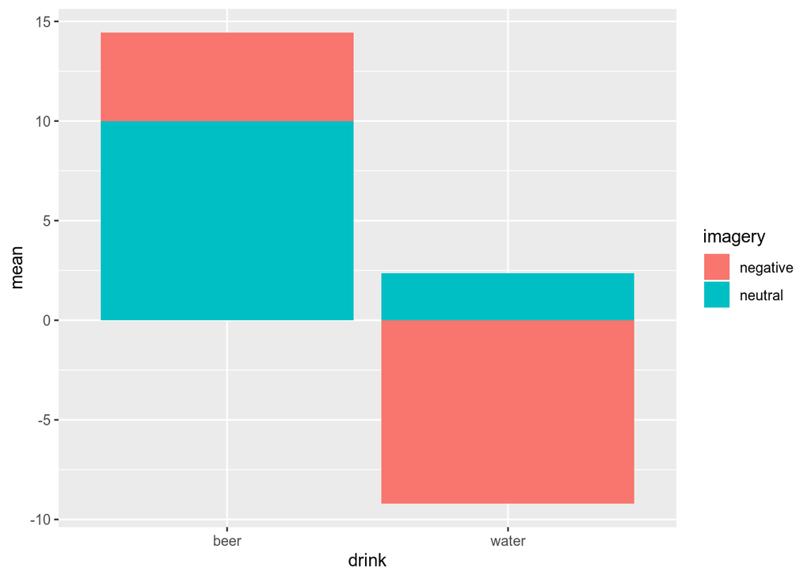

```r
summary.att.filter.select.recode.long.sep %>%
  ggplot(
    ., # data
    aes(
      x = drink, # 'drink' variable on x-axis
      y = mean, # mean ratings on y-axis
      fill = imagery
    )
  ) + # separate colors for each level of 'imagery'
  geom_bar(stat = "identity") # use the values in the data frame (no transformations)
```

What the hell is that?!? Oh no, it’s a **stacked bar graph**! We don’t want that! How can we get separate bars for negative and neutral imagery?

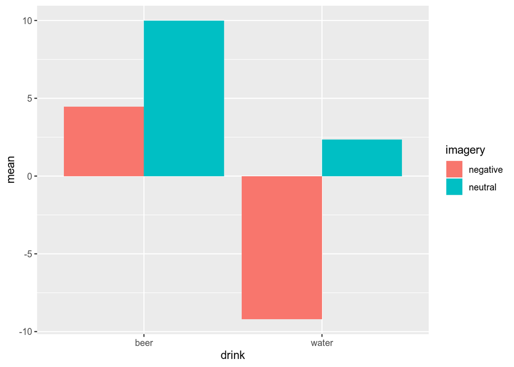

```r
summary.att.filter.select.recode.long.sep %>%
  ggplot(
    .,
    aes(
      x = drink,
      y = mean,
      fill = imagery
    )
  ) +
  geom_bar(
    stat = "identity",
    position = position_dodge()
  ) # bars are next to each other
```

Better. Let’s add outlines.

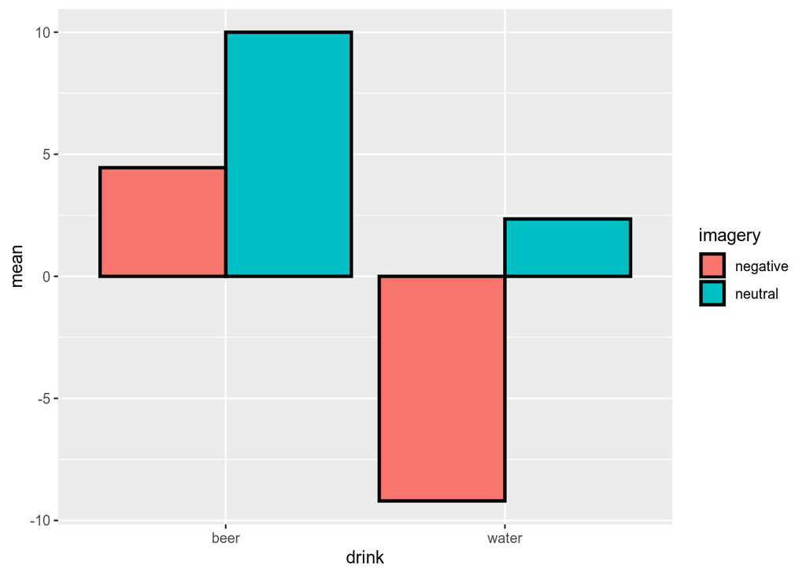

```r
summary.att.filter.select.recode.long.sep %>%
  ggplot(
    .,
    aes(
      x = drink,
      y = mean,
      fill = imagery
    )
  ) +
  geom_bar(
    stat = "identity",
    position = position_dodge(),
    color = "black", # black outlines
    size = 1
  ) # line thickness
```

Something is missing… ah, error bars! Display 95% confidence intervals.

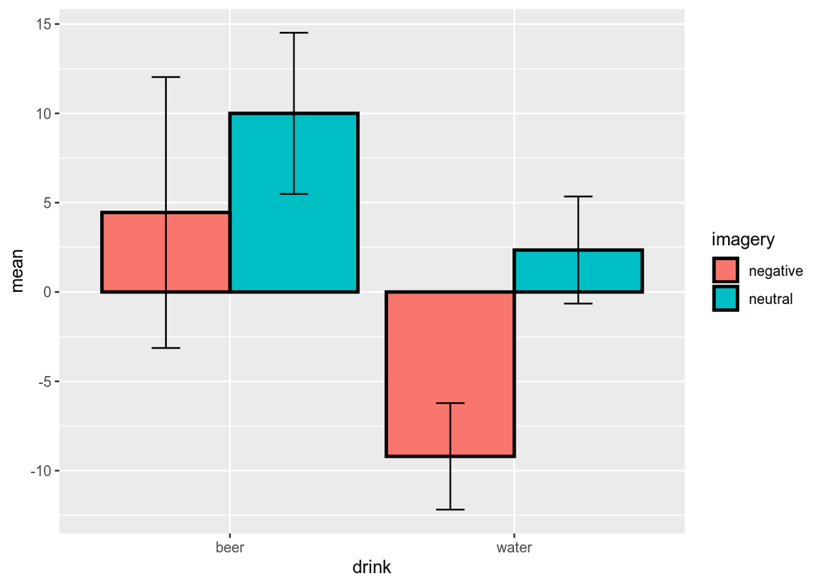

```r
summary.att.filter.select.recode.long.sep %>%
  ggplot(
    .,
    aes(
      x = drink,
      y = mean,
      fill = imagery
    )
  ) +
  geom_bar(
    stat = "identity",
    position = position_dodge(),
    color = "black",
    size = 1
  ) +
  geom_errorbar(aes(
    ymin = mean - ci.95, # mean ratings ± 95% confidence interval
    ymax = mean + ci.95
  ),
  width = .2, # width of the error bars
  position = position_dodge(.9)
  ) # position (centered on the bar)
```

These colors are hideous… let’s use a more decent color palette.

The package `viridis` uses colors that are easier to distinguish for people with colorblindness.

```r
install.packages("viridis")
```

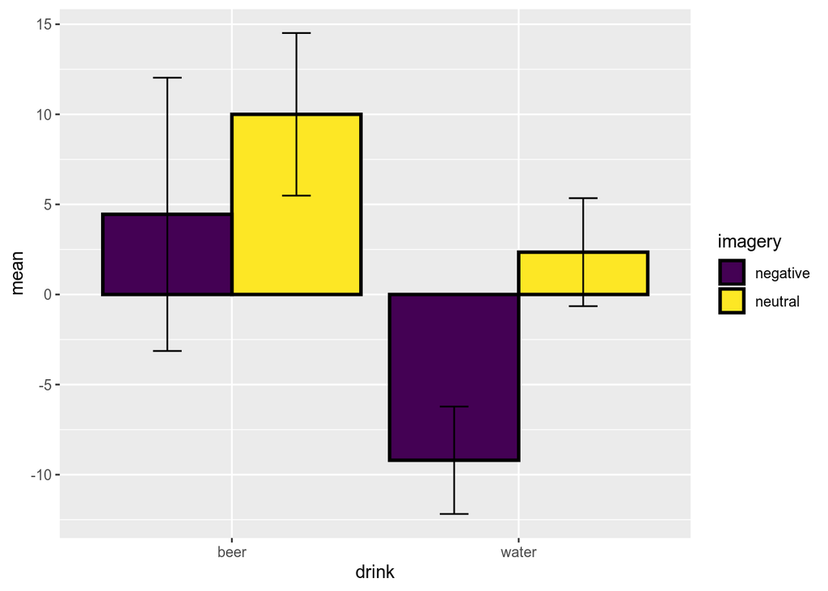

```r
library(viridis)

summary.att.filter.select.recode.long.sep %>%
  ggplot(
    .,
    aes(
      x = drink,
      y = mean,
      fill = imagery
    )
  ) +
  geom_bar(
    stat = "identity",
    position = position_dodge(),
    color = "black",
    size = 1
  ) +
  geom_errorbar(aes(
    ymin = mean - ci.95,
    ymax = mean + ci.95
  ),
  width = .2,
  position = position_dodge(.9)
  ) +
  scale_fill_viridis(
    option = "viridis", # see ?scale_color_viridis for other color palettes
    discrete = TRUE
  ) # map colors to discrete values
```

Let’s add a final cosmetic touch.

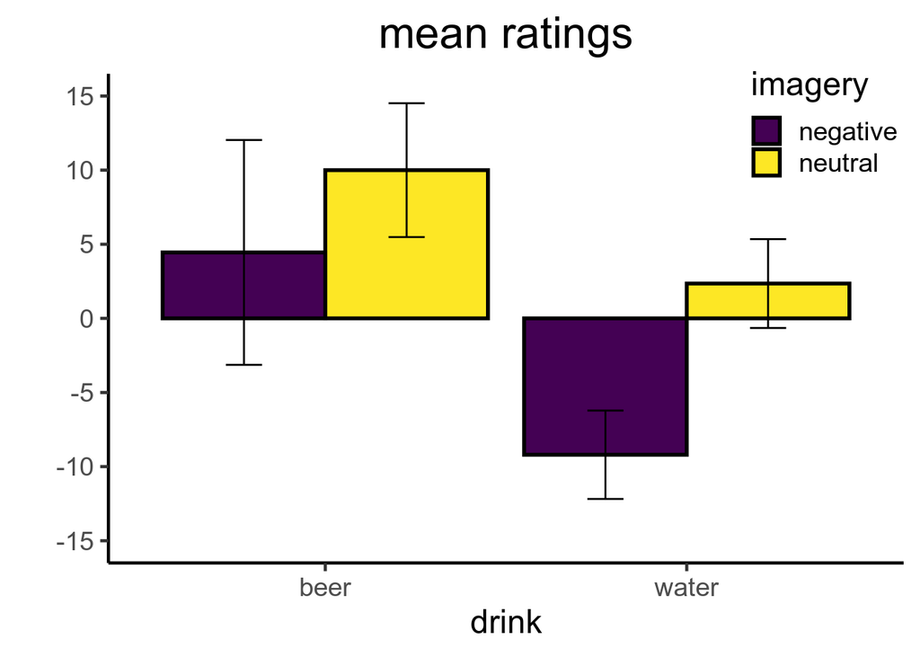

```r
summary.att.filter.select.recode.long.sep %>%
  ggplot(
    .,
    aes(
      x = drink,
      y = mean,
      fill = imagery
    )
  ) +
  geom_bar(
    stat = "identity",
    position = position_dodge(),
    color = "black",
    size = 1
  ) +
  geom_errorbar(aes(
    ymin = mean - ci.95,
    ymax = mean + ci.95
  ),
  width = .2,
  position = position_dodge(.9)
  ) +
  scale_fill_viridis(
    option = "viridis",
    discrete = TRUE
  ) +
  scale_y_continuous("", # y-axis: no title
    limits = c(-15, 15), # y-axis: min/max values
    breaks = seq(-15, 15, 5)
  ) + # y-axis: tick marks
  ggtitle("mean ratings") + # plot title
  theme_classic(base_size = 18) + # text size
  theme(
    plot.title = element_text(
      size = 24, # title: text size
      hjust = .5
    ), # title: centered
    legend.position = c(.9, .9)
  ) # legend position (upper right corner)
```

## RDI plots

No matter how pretty a bar graph is, it remains a suboptimal way of displaying your data.  
A better solution is to use **RDI** plots, which show **R**aw data, **D**escriptive & **I**nferential statistics.

The following graph shows:

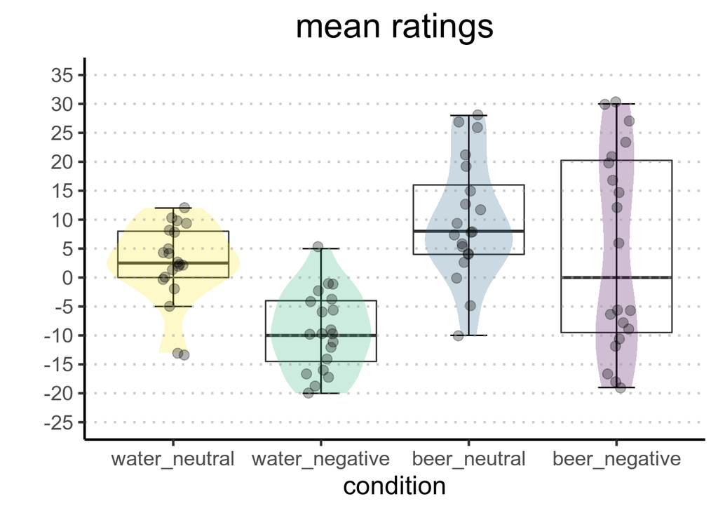

```r
att.filter.select.recode.long.sep %>% # we need the complete data frame, not the summary
  unite("condition", c(drink, imagery)) %>% # paste 'drink' and 'imagery' columns into 'condition'
  # base plot
  ggplot(
    .,
    aes(
      x = condition,
      y = ratings
    )
  ) +
  # box and whisker plot
  geom_boxplot(
    alpha = 1, # boxes: transparency
    size = .5, # boxes: line thickness
    outlier.alpha = 0
  ) + # outliers: transparency
  stat_boxplot(
    geom = "errorbar", # whiskers
    size = .5, # whiskers: line thickness
    width = .25
  ) + # whiskers: width
  # violin plot
  geom_violin(aes(fill = condition), # density: color fill
    color = "transparent", # outline: color
    alpha = .25
  ) + # density: transparency
  # jittered data points
  geom_jitter(
    size = 3, # point: size
    alpha = .3, # point: transparency
    position = position_jitter(width = .1)
  ) + # point: jitter
  scale_fill_viridis(
    option = "viridis", # color palette for all fills
    discrete = TRUE
  ) +
  scale_color_viridis(
    option = "viridis", # color palette for all outlines
    discrete = TRUE
  ) +
  scale_x_discrete(
    limits = # x-axis: set variable order
    c(
      "water_neutral", "water_negative",
      "beer_neutral", "beer_negative"
    )
  ) +
  scale_y_continuous(
    name = "", # y-axis: title
    limits = c(-25, 35), # y-axis: min/max values
    breaks = seq(-25, 35, 5)
  ) + # y-axis: tick marks
  geom_hline(
    yintercept = seq(-25, 35, 5), # reference lines
    linetype = "dotted", # reference lines: type
    colour = "#999999", # reference lines: color
    size = .8, # reference lines: thickness
    alpha = .5
  ) + # reference lines: transparency
  ggtitle("mean ratings") + # plot title
  theme_classic(base_size = 18) + # custom theme (resize text)
  theme(
    legend.position = "none", # no legend
    plot.title = element_text(size = 24, hjust = .5)
  ) # resize and center title
```

If you don’t want to waste time doing it yourself, I recommend the [`yarrr`](https://cran.r-project.org/web/packages/yarrr/vignettes/pirateplot.html) package.

```r
install.packages("yarrr")
```

The `pirateplot` function creates a graph showing:

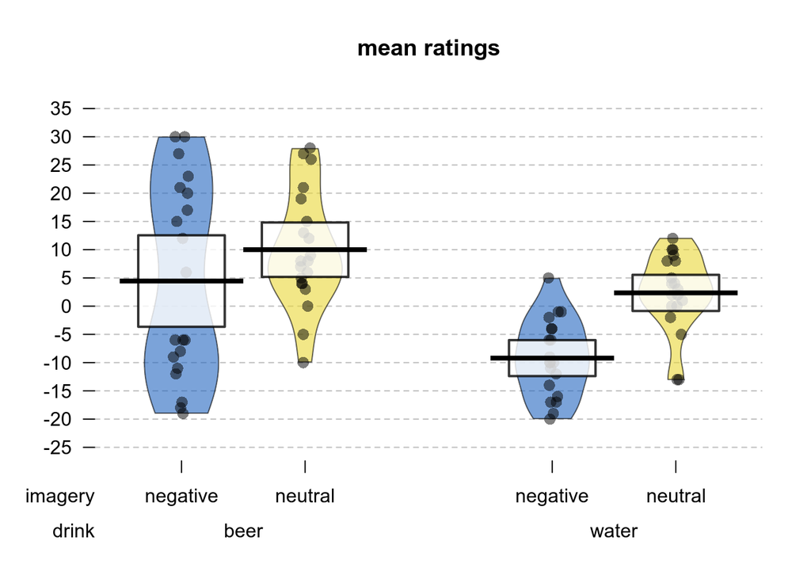

```r
library(yarrr)

pirateplot(
  formula = ratings ~ imagery + drink, # dependent ~ independent variables
  data = att.filter.select.recode.long.sep, # data frame
  main = "mean ratings", # plot title
  ylim = c(-25, 35), # y-axis: axis limits
  ylab = "", # y-axis: no label
  inf.method = "ci", # type of inference: 95% confidence interval
  inf.within = participant, # ID variable
  # theme settings
  pal = "espresso", # color palette: see piratepal("all")
  point.o = .5, # data points: opacity (0-1)
  point.cex = 1.3, # data points: size
  bean.b.o = .6, # bean border: opacity (0-1)
  bean.f.o = .6, # bean filling: opacity (0-1)
  cap.beans = TRUE, # bean densities are capped at the data limits
  bty = "n", # no box around the plot
  gl.col = "gray", # background line color (major and minor lines)
  gl.lwd = 1, # background line width
  gl.lty = 2
) # background line type (dashed)
```

The graphs above suggest that negative imagery may have influenced ratings to water more than to beer.

# Exercises

## Exercise 2.1

Compute the following operations **in one go**:

- load `data_attitude_exercise.csv` (use a function from the `tidyverse` instead of `read.table`)
- separately for **drink**, **imagery**, and **gender**, calculate the summary statistics that you will need for the plot (i.e., means and 95% confidence intervals)
- create bar graphs:
  - separate bars for negative and neutral imagery
  - separate graphs for **male** and **female** participants, placed horizontally (**hint**: use `facet_grid`)
  - black outlines
  - error bars displaying 95% confidence intervals
  - `viridis` color palette
  - no title on the *x*-axis
  - limit the *y*-axis from -20 to +20, with tick marks every 5
  - add a plot title
  - text size in the plot: 18 points
  - text size of the title: 32 points
  - title in the center
  - legend position in the center of the graph (not overlapping with the bars)
  - no legend title
  - no legend background

```r
################################################
############### INSERT CODE HERE ###############
################################################
```

## Exercise 2.2

Compute the following operations **in one go**:

- load `data_attitude_exercise.csv`
- using the `yarrr` package, create an RDI graph similar to the bar graph of **Exercise 2.1** (i.e., separate graphs for female and male participants)
- modify it as you please (check the `pirateplot` options), e.g., change color palette (**hint**: type `piratepal("all")`)

```r
################################################
############### INSERT CODE HERE ###############
################################################
```

# Data analysis

The aim of this study was to assess whether negative imagery would influence the likeness ratings of alcoholic beverages. It’s time to statistically verify this hypothesis.

We will run a 2 (**drink**: water, beer) x 2 (**imagery**: neutral, negative) repeated measures ANOVA on these ratings.

For this demonstration I chose the package `afex`, authored by [Henrik Singmann](http://singmann.org/about-me/).

```r
install.packages("afex") # 'afex' also installs many other useful packages... including 'brms'!
```

## Repeated measures ANOVA

The code below shows how to run an ANOVA with this versatile and user-friendly package.

```r
library(afex)
library(multcomp) # we didn't explicitly install this package, but it's part of the dependencies of 'afex'

rmANOVA.att <- aov_ez("participant", # variable with subject identifier
  "ratings", # dependent variable
  att.filter.select.recode.long.sep, # data frame
  within = c("drink", "imagery"), # within-subject variables
  type = 3
) # type-III sums of squares (default in SPSS)

rmANOVA.att
```

```
## Anova Table (Type 3 tests)
##
## Response: ratings
##          Effect    df    MSE         F ges p.value
## 1         drink 1, 19 252.84   8.97 ** .19    .007
## 2       imagery 1, 19  82.92 17.63 *** .13   .0005
## 3 drink:imagery 1, 19  26.66    6.75 * .02     .02
## ---
## Signif. codes:  0 '***' 0.001 '**' 0.01 '*' 0.05 '+' 0.1 ' ' 1
```

The results show:

- a statistically significant main effect of **drink** (*F*<sub>(1, 19)</sub> = 8.97, *p* = 0.007, $\eta$<sup>2</sup><sub>G</sub> = 0.19)
- a statistically significant main effect of **imagery** (*F*<sub>(1, 19)</sub> = 17.63, *p* = 0.00049, $\eta$<sup>2</sup><sub>G</sub> = 0.13)
- a statistically significant **drink x imagery** interaction (*F*<sub>(1, 19)</sub> = 6.75, *p* = 0.018, $\eta$<sup>2</sup><sub>G</sub> = 0.02)

## Paired contrasts

The **drink x imagery** interaction is statistically significant… let’s run paired comparisons. `afex` uses functions included in the `emmeans` and `multcomp` packages.

```r
library(emmeans) # we didn't explicitly install this package, but it's part of the dependencies of 'afex'
```

```r
# set afex_options as below to use appropriate degrees of freedom (not Satterthwaite approximated)
# for details, see https://cran.r-project.org/web/packages/afex/vignettes/afex_anova_example.html#post-hoc-contrasts-and-plotting
afex_options(emmeans_model = "multivariate")

posthoc.att <-
  emmeans(rmANOVA.att, ~ imagery:drink) %>% # estimated marginal means
  pairs(., # compare differences between estimated marginal means
    test = adjusted("free")
  ) %>% # "free": generalization of Bonferroni-Holm correction, taking into account correlations among model parameters
  as.glht(.) %>% # better p-value adjustment for multiple testing
  summary(.) %>% # cleaner output
  print(.)
```

```
##
##   Simultaneous Tests for General Linear Hypotheses
##
## Linear Hypotheses:
##                                     Estimate Std. Error t value Pr(>|t|)
## negative,beer - neutral,beer == 0     -5.550      2.604  -2.131   0.1422
## negative,beer - negative,water == 0   13.650      4.329   3.153   0.0192 *
## negative,beer - neutral,water == 0     2.100      4.997   0.420   0.9613
## neutral,beer - negative,water == 0    19.200      2.934   6.544   <0.001 ***
## neutral,beer - neutral,water == 0      7.650      3.034   2.521   0.0690 .
## negative,water - neutral,water == 0  -11.550      2.044  -5.652   <0.001 ***
## ---
## Signif. codes:  0 '***' 0.001 '**' 0.01 '*' 0.05 '.' 0.1 ' ' 1
## (Adjusted p values reported -- single-step method)
```

The output has all you need to report in a publication… well, almost. Something is missing.

## Effect sizes

It is good practice to report **effect sizes** along with *p*-values, so that readers can make their own mind with respect to the importance of the observed effects. Even better, you could report **confidence intervals** around effect sizes, so that readers can have a clear picture of the *precision* of your estimation.

I particularly like the idea of **bootstrapping** effect sizes, a better approach when the data are known not to be normally distributed or when the distribution is unknown[^4]. I will show you how to do it using the package `bootES`[^5].

```r
install.packages("bootES")
```

We will compute **Hegdes’s *g***, an unbiased estimate of $\delta$ (for details, see [here](http://journals.sagepub.com/doi/abs/10.1177/0013164404264850))

Because our dependent variable consists of ratings collected from the same participants in different conditions (i.e., repeated measures), we must first manually compute the difference scores between our contrasts of interest (see the output of the paired comparisons above).

```r
att.bootES <-
  att.filter.select.recode.long.sep %>%
  unite("condition", c(drink, imagery)) %>% # create 'condition' variable
  spread(condition, ratings) %>% # convert from long to wide format
  # compute mean differences
  mutate(
    beer_negativeVSbeer_neutral = beer_negative - beer_neutral,
    beer_negativeVSwater_negative = beer_negative - water_negative,
    beer_negativeVSwater_neutral = beer_negative - water_neutral,
    beer_neutralVSwater_negative = beer_neutral - water_negative,
    beer_neutralVSwater_neutral = beer_neutral - water_neutral,
    water_negativeVSwater_neutral = water_negative - water_neutral
  ) %>%
  # delete unused variables
  # here we must specify that we want to use the 'select' function from 'dplyr' (part of the 'tidyverse'), because there is another function ('lm.ridge' in the 'MASS' package) that creates conflict
  dplyr::select(-c(beer_negative:water_neutral)) %>%
  # re-convert to long format
  gather(
    key = "diff.conds",
    value = "ratings",
    beer_negativeVSbeer_neutral:water_negativeVSwater_neutral
  )

head(att.bootES, n = 5)
```

|  | participant | sex | diff.conds | ratings |
| --- | --- | --- | --- | --- |
| 1 | 1 | female | beer_negativeVSbeer_neutral | 1 |
| 2 | 10 | female | beer_negativeVSbeer_neutral | 0 |
| 3 | 11 | male | beer_negativeVSbeer_neutral | -9 |
| 4 | 12 | male | beer_negativeVSbeer_neutral | -24 |
| 5 | 13 | male | beer_negativeVSbeer_neutral | -12 |

Now we can calculate the standardized effect size for each difference scores. Using functions in the `purrr` package (part of the `tidyverse`!), we will create separate lists for each difference score and calculate bootstrapped Hegdes’s *g* for each of them.

```r
library(bootES)

att.HedgesG <-
  att.bootES %>%
  split(.$diff.conds) %>% # split difference scores in separate lists
  # apply bootES function to all lists
  map(~ bootES(., # data
    data.col = "ratings", # dependent variable
    R = 5000, # number of samples
    effect.type = "hedges.g", # type of effect size
    ci.type = "bca", # bootstrap method
    ci.conf = .95
  )) # confidence level
```

The result is a data frame containing 6 lists (i.e., the number of `diff.conds`), each containing the results of the bootstrapping procedure. As an example, let’s look at the list containing the bootstrapped Hegdes’s *g* for the difference ratings of beer after seeing negative vs. neutral imagery:

```r
att.HedgesG$beer_negativeVSbeer_neutral
```

```
##
## 95.00% bca Confidence Interval, 5000 replicates
## Stat        CI (Low)    CI (High)   bias        SE
## -0.457      -0.933      0.031       -0.032      0.251
```

## Summary of paired contrasts

The final step is to summarize the information stored in different lists in one single data frame that can later be converted into a table and cleaned up for publication. This is one way to do it:

```r
# initialize summary table: what do you want to report?
summary.att.bootES <- data.frame(magrittr::extract2(posthoc.att, 1)$object, # extract2, a function of 'magrittr' (part of the 'tidyverse'!), extracts values from lists (similarly to [[]] in base R)
  "Hedges.g" = NA,
  "CI.95.low" = NA,
  "CI.95.high" = NA,
  "bias" = NA,
  "std.error" = NA
)

# OH MY GOD A LOOP IN R!
for (i in 1:length(unique(att.bootES$diff.conds))) { # loop through conditions
  summary.att.bootES[i, 7:11] <- summary(magrittr::extract2(att.HedgesG, i)) # extract values from the list with bootstrapped Hedges's g
}

summary.att.bootES
```

|  | contrast | estimate | SE | df | t.ratio | p.value | Hedges.g | CI.95.low | CI.95.high | bias | std.error |
| --- | --- | --- | --- | --- | --- | --- | --- | --- | --- | --- | --- |
| 1 | negative,beer - neutral,beer | -5.55 | 2.604121 | 19 | -2.1312372 | 1.791246e-01 | -0.45745404 | -0.93280227 | 0.03083605 | -0.032085543 | 0.2507778 |
| 2 | negative,beer - negative,water | 13.65 | 4.329382 | 19 | 3.1528746 | 2.471480e-02 | 0.67674082 | 0.24862527 | 1.16773945 | 0.030128010 | 0.2356098 |
| 3 | negative,beer - neutral,water | 2.10 | 4.996788 | 19 | 0.4202699 | 9.743222e-01 | 0.09020778 | -0.36233148 | 0.55036480 | -0.000228218 | 0.2246922 |
| 4 | neutral,beer - negative,water | 19.20 | 2.934011 | 19 | 6.5439426 | 1.599389e-05 | 1.40460806 | 0.80767989 | 2.02459597 | 0.085885282 | 0.3477744 |
| 5 | neutral,beer - neutral,water | 7.65 | 3.034256 | 19 | 2.5212110 | 8.845554e-02 | 0.54115898 | 0.07244528 | 1.02656252 | 0.029746852 | 0.2479614 |
| 6 | negative,water - neutral,water | -11.55 | 2.043571 | 19 | -5.6518700 | 1.033040e-04 | -1.21313139 | -2.28947882 | -0.53898451 | -0.148597151 | 0.5424504 |

# Exercises

## Exercise 3.1

Run the same analyses using the exercise dataset (i.e., wine instead of beer):

- 2 (**drink**) x 2 (**imagery**) repeated measures ANOVA on likeness ratings
- paired contrasts
- bootstrapped effect sizes (calculate **Pearson’s *r*** instead of Hegdes’s *g*)
- summary table of paired contrasts

```r
################################################
############### INSERT CODE HERE ###############
################################################
```

## Exercise 3.2

Run a 2 (**gender**) x 2 (**drink**) x 2 (**imagery**) mixed ANOVA on likeness ratings:

- remember: `gender` is a between-subject factor!
- paired contrasts: test **only** difference ratings between *female* and *male* participants (**hint**: see example [here](https://cran.r-project.org/web/packages/afex/vignettes/afex_anova_example.html#post-hoc-contrasts-and-plotting)):
  - wine_negative
  - wine_neutral
  - water_negative
  - water_neutral
- bootstrapped effect sizes (**Cohen’s *d***) of the paired comparisons of interest
- summary table of paired contrasts

```r
################################################
############### INSERT CODE HERE ###############
################################################
```

# Conclusion

Hopefully, I managed to give you a glimpse of the versatility, readability, and user-friendliness of the `tidyverse`. Enjoy your tidy new life!

Thanks!

[^1]: Hopefully you’re not familiar with **pretending** to collect data… if so, please tell your story by writing a [book](http://nick.brown.free.fr/stapel/FakingScience-20161115.pdf).
[^2]: As you may imagine, today we won’t have time to cover all the amazing things you can do with these packages. Also, they are a gift that keeps on giving: I have been using them for a while and I keep discovering useful functions. If you want to learn more, read [R for Data Science](http://r4ds.had.co.nz/) by [Garrett Grolemund](https://www.oreilly.com/pub/au/5570) and [Hadley Wickham](http://hadley.nz/).
[^3]: This is a modified version of a dataset included in the book [Discovering Statistics Using R (Field, Miles & Field, 2012)](https://www.discoveringstatistics.com/books/discovering-statistics-using-r/).
[^4]: If you prefer **not** to bootstrap your effect sizes, you can use the `MBESS` package (a useful tutorial can be found [here](http://osc.centerforopenscience.org/2014/03/06/confidence%20intervals/)). If you want to do it in **SPSS**, see [here](https://daniellakens.blogspot.be/2014/06/calculating-confidence-intervals-for.html).
[^5]: A clear explanation of how to use `bootES` is provided by the authors of the package in their [paper](https://link.springer.com/article/10.3758/s13428-013-0330-5).

[Antonio Schettino](https://asch3tti.netlify.com/)

*schettino@eur.nl*